# RaceReport

## Fantasy League Scores

Scores for drivers/constructors in the current year's fantasy league, along with manager/team points, values, and statistics. Note: driver and constructor values are taken as the cost to enter the current race and are updated the week before the race.

## Lineup Scores

After storming up the field, George Russell took the top step this week with 37 points, just one ahead of race winner Lando Norris. Oscar Piastri took a distant third place with 29, ahead of Kick Sauber's Gabriel Bortoleto with 24. Despite a late-race penalty, Charles Leclerc rounds out the top five with 20 points. At the bottom of the field, Oliver Bearman takes the honours with -18 points this week. He's behind Franco Colapinto with -4 and Pierre Gasly with 0. Then, it's Yuki Tsunoda, who suffers another bad week with 3 points, behind Isack Hadjar and Lewis Hamilton with a pair of 4s.

McLaren take another win this week with a very satisfying 100 points, almost double Mercedes' haul in second with 54 points, and Aston Martin in third with 45. Haas take the lowest score of the week with -9 points, behind Alpine with 2. Williams round out the bottom three with 24.

McLaren are in a different league out front with 1215 points, ahead of Ferrari with 713 and Mercedes with 605. Alpine remain in double figures with 67 points, behind Racing Bulls and Williams with 211. Aston Martin round out the bottom three with 220.

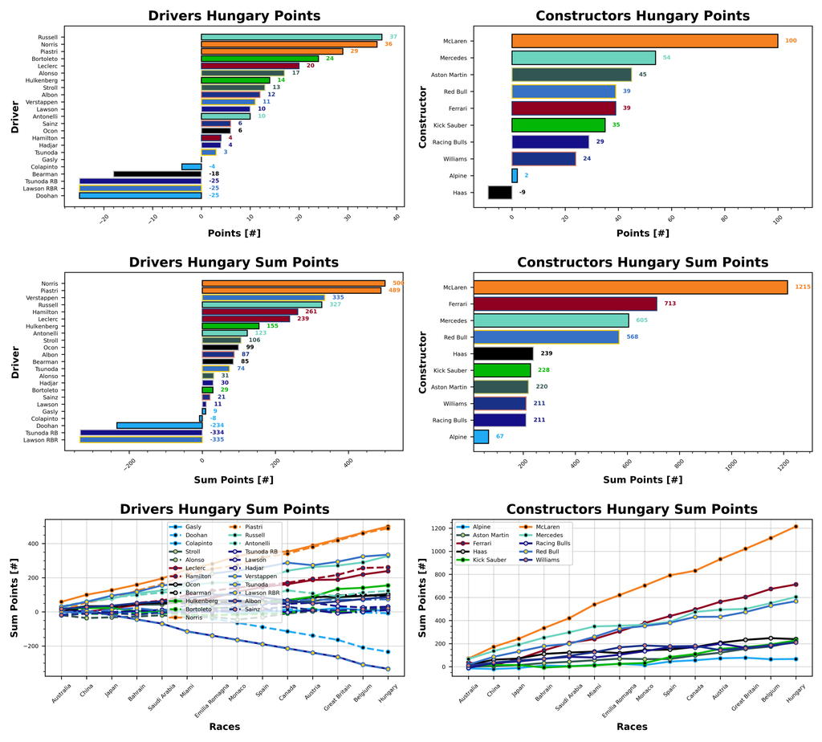

Lando's value rises back up to 31.1 this week, ahead of reigning champion Verstappen at 28.3. Piastri continues to rise with a value of 26.1, ahead of Leclerc and Hamilton at 24.0 and 23.7, respectively. Colapinto and Lawson were your cheapest option this week at 4.5, behind Bortoleto at 4.7. Hadjar remains great value at 5.7, behind Gasly at 6.0. Carlos Sainz rounds out your cheap 5 at 6.5. McLaren cost you 33.9 this week, while Ferrari and Red Bull behind set you back 30.0 and 28.1, respectively. Kick Sauber were your cheapest option at 8.7, behind Alpine at 8.9. Aston Martin were in third at 10.7.

All values are in Million Dollars.

George Russell and Oscar Piastri maintain their 100% positive score, ahead of Verstappen, Ocon, Norris, and Hamilton with 93%. Colapinto is by far the lowest percentage, at 29%, behind Gasly, Lawson, and Tsunoda at 57%. Some of these are affected by 0 scores for inactive tokens. Red Bull, Mercedes, and McLaren continue their 100% record, while Alpine represent your worst team of the season with a 64% positive score.

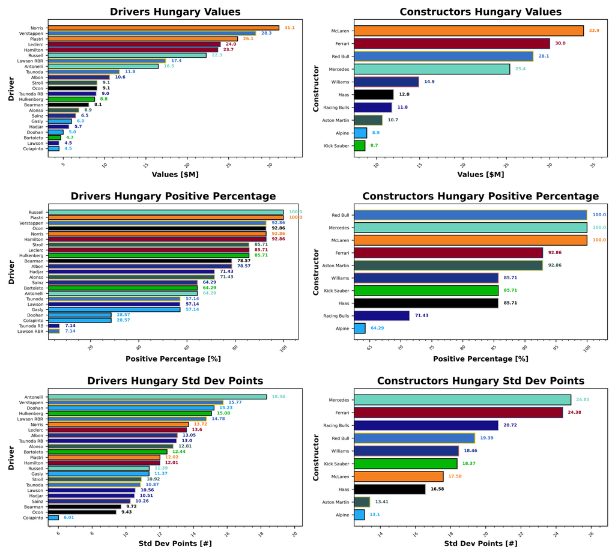

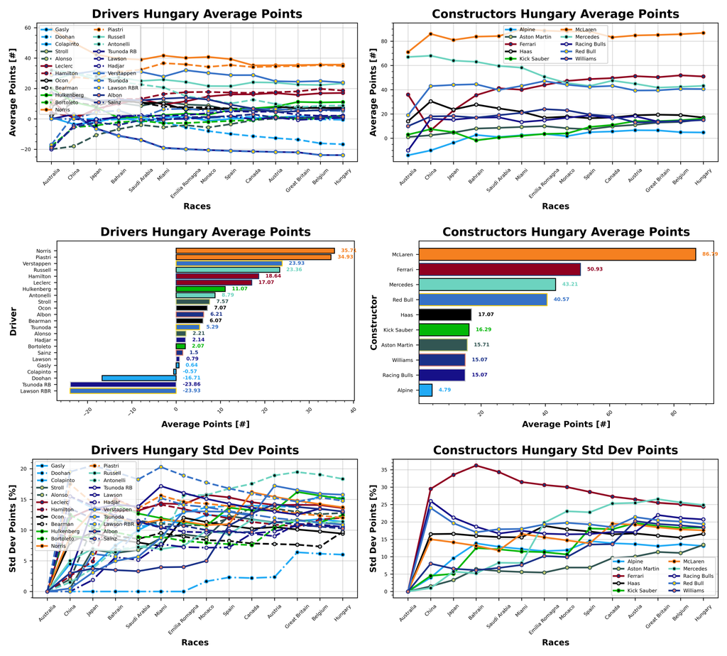

Gabriel Bortoleto was your driver of the week this week, with a points per value of 5.11 ppm. Fernando Alonso finally turns his season around in second with 2.46 ppm, ahead of Liam Lawson with 2.22 ppm. George Russell is in fourth with 1.66 ppm, ahead of Nico Hulkenberg with 1.59 ppm. Oliver Bearman was your worst driver of the week with -2.22 ppm, behind Colapinto with -0.89 ppm. Pierre Gasly scored a 0 ppm, behind Lewis Hamilton with 0.17 ppm. Yuki Tsunoda rounds out the bottom five with 0.25 ppm.

Aston Martin were your team of the week with 4.21 ppm ahead of Kick Sauber with 4.02 ppm. McLaren were a distant third with 2.95 ppm. Haas were your worst team of the week with -0.75 ppm, behind Alpine with 0.22 ppm and Ferrari with 1.3 ppm.

ppm = points per million Dollars.

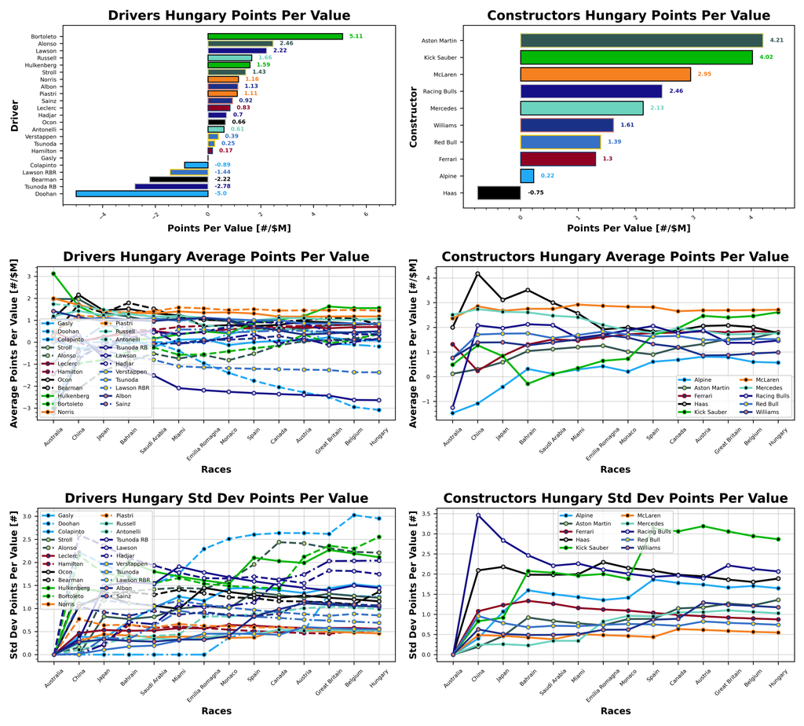

### Manager Scores

Stefanus and Haryanto took the top step this week with 301 points, ahead of Jake and Kick Sauber In The Audi with 286. Phil makes a top three appearance with BMW FTW and 253 points, just beating Stefanus and Syahrul with 251 points. Phil rounds out the top five with BMW Motorrad and 244 points.

Valerie takes the honours at the bottom of the table this week with 9 points for Perez For World Champion, ahead of Patrick and Coming In Haast Place with 17. Stuart and Taylormade to Lose are next with 21 points, ahead of Valerie and Stroll To The 18th with 36 points. Valerie makes it three for three in the bottom five with What Arrrgh Ya Doohan bringing in 47 points.

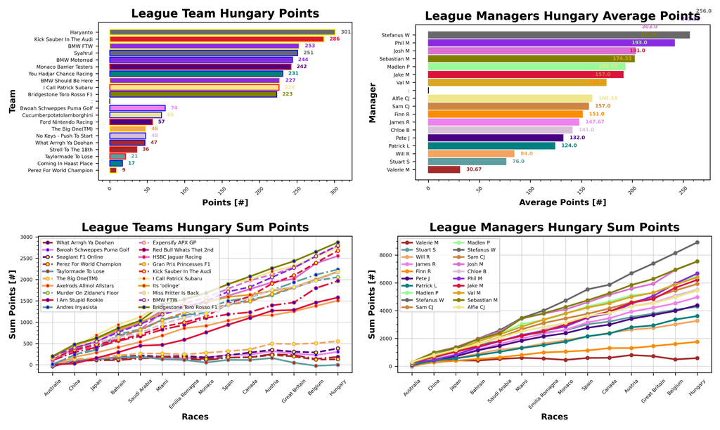

Stefanus slips this week, now only holding onto 1-2 in the championship with Syahrul and Haryanto with 3128 and 2924 points. Sebastian moves up into third with Bridgestone Toro Rosso F1 and 2874 points, with Stefanus and Gelael dropping to fourth with 2866. Patrick and You Hadjar Chance Racing round out the top five with 2836 points.

Stuart holds onto the lead in the Golf League with Taylormade To Lose and -2 points. Valerie is in second, third, and fourth with 130, 186, and 274 points for Perez For World Champion, What Arrrgh Ya Doohan, and Stroll To The 18th. James and Bwoah Schweppes Puma Golf are next with 303 points, ahead of Alfie and Cucumberpotatolamborghini with 374 points.

Biggest winner of the week was Chloe with Miss Fritter Is Back jumping 4 places in the standings. Biggest losers this week were Stuart, Madlen, and Sam, with their teams Andres Inyasista, Murder on Zidane's Floor, Push Push - Box Now Too, and Total F1 Performance losing 2 places each.

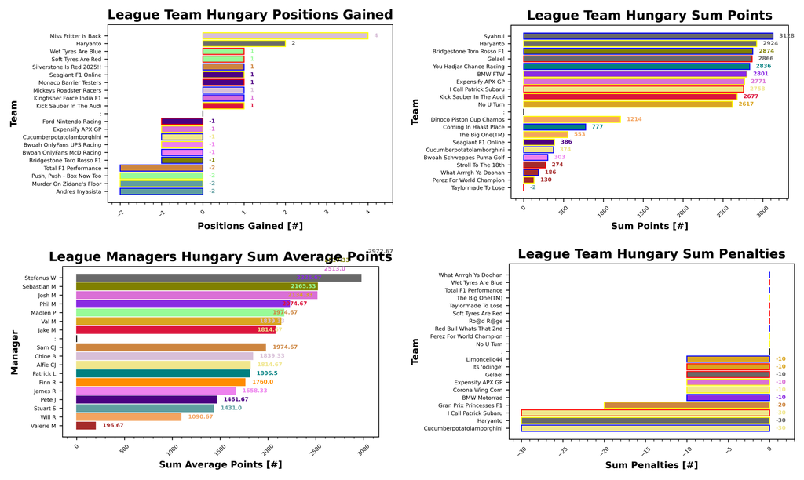

Hadjar's popularity continues with 27 of you including the Frenchman in your teams. Oscar Piastri is second with 23 selections, ahead of Hulkenberg, Alonso, Sainz-Lawson-Bearman with 20, 19, and 14 selections each. Yuki Tsunoda maintains his poor selection, joined by teammate Verstappen this week with 2 selections. Antonelli and Hamilton are next with only 4, followed by Gasly, Leclerc-Norris, and Ocon-Russell-Stroll with 6, 8, and 9 selections.

McLaren, Kick Sauber, and Ferrari are your most selected teams with 19, 16, and 12 selections. Mercedes continue their run as your least selected team with only 4 this week, behind Red Bull and Williams with 5, and Alpine with 6.

Oscar Piastri makes 19 DRS Boost selections this week ahead of Norris with only 6. Doohan's inactive token is doubled 5 times, ahead of Leclerc with 4 and Bortoleto with 3. Only a wildcard and a limitless token this week.

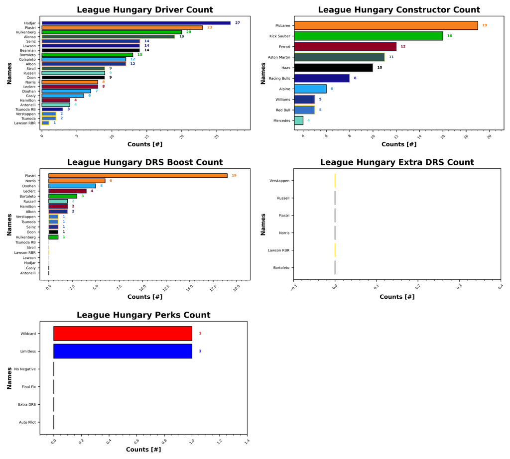

## Prizes

I have now updated the prizes plotting for my code and we should be able to track the season long prizes with ease. So without further adieu, let's take a look at what is currently in play this season.

### Championship

| Prize Name | Prize Value | Terms |
| --- | --- | --- |
|  | (%) |  |
| Champion of the World | 20 | Awarded to the top scorer in the league at the end of the season |
| If You're Not First, You're Last | 10 | Awarded to the second place scorer in the league at the end of the season |
| Alpine Podium | 5 | Awarded to the third place scorer in the league at the end of the season |
| Above Par | 20 | Awarded to the lowest scorer in the league at the end of the season, commonly referred to as the Golf League |

### Achievements

| Prize Name | Prize Value | Terms |
| --- | --- | --- |
|  | (%) |  |
| Cost Cappen | 5 | Highest average points per value at the end of the season |
| Sprint King | 5 | Highest score across the sprint races (China, Miami, Belgium, United States, Brazil, Qatar) |
| Flavio Controls Every Millimeter | 5 | Manager wide substitution count, highest wins |
| The Triple Header | 5 | Highest score across the triple header races (Japan, Bahrain, Saudi Arabia, Emilia Romagna, Monaco, Spain, Las Vegas, Qatar, Abu Dhabi) |
| I Forgot I Was Taking Part | 5 | Highest score in the first part of the season |
| Zak's Master Plan | 5 | Lowest score in the second half of the season |
| Mega Driver | 5 | Highest Extra DRS token score |
| The Continental | 5 | Highest score across all 5 continents, Mexico classed as South America for inclusion only (Australia, Canada, Great Britain, Azerbaijan, Mexico) |

### Spot Prizes

| Prize Name | Prize Value | Terms |
| --- | --- | --- |
|  | (%) |  |
| The Ring | 1 | Highest score at the Austrian Grand Prix |
| Bottas Bowling | 1 | Highest score at the Hungarian Grand Prix |
| Daniel's Broken Hand | 1 | Lowest score at the Netherlands Grand Prix |
| The Tifosi | 1 | Lowest score at the Italian Grand Prix |
| Go For The Gap | 1 | Lowest score at the Singapore Grand Prix |

**We have developed another problem with the spot prizes this week and I will be using the summer break to fix this issue, please excuse this. It's difficult to scan through the data in the form I keep it, and occasionally things go wrong like this.**

### Cost Cappen

Stefanus and Syahrul sit at the top of this table, with a points per value of 2.05 ppm. Patrick and You Hadjar Chance Racing are in second with 2.02, ahead of Sebastian and Bridgestone Toro Rosso F1 with 2.01 ppm.

### Flavio Controls Every Millimeter

Stefanus and Gelael lead this one with 36 substitutes, ahead of their other team Haryanto with 34. Josh and Kingfisher Force India F1 are in third with 33, tied with their other team Expensify APX GP.

### Mega Driver

Check back later!

### I Forgot I Was Taking Part

I Forgot I Was Taking Part comes to a close, with Stefanus and Syahrul taking the top step with 3128 points. Haryanto is in second with 2924 points, and Sebastian and Bridgestone Toro Rosso F1 rounds out the podium with 2874 points.

### Zak's Master Plan

Check back after the season break!

## F1 Predict

Josh takes the top step this week with 52 points, ahead of Phil in second with 47 and Val in third with 46. Stuart is in fourth place with 31 points, while Pierce and Matty continue their run of 0s.

That means, Stu holds on to their lead with 787 points, ahead of Phil in second with 767. Val holds on to third place with 690, and Josh is in fourth with 652. Pierce and Matty stay put with 248 and 95.

## Next Up

Next up we have the Dutch Grand Prix, coming from the beach resort of Zandvoort. Best of luck and enjoy the summer break!